# Risk Factor Analysis

## Outcome Variable

**Outcome Variable:** sstunted

## Predictor Variables

**Intervention Variable:** mbmi

**Adjustment Set:**

- arm
- W_mage
- W_fage
- meducyrs
- feducyrs
- single
- brthmon
- delta_W_mage
- delta_W_fage
- delta_meducyrs
- delta_feducyrs
- delta_single
- delta_brthmon

## Stratifying Variables

The analysis was stratified on these variable(s):

- agecat
- studyid
- country

## Data Summary

| agecat | studyid | country | mbmi | sstunted | n_cell | n |
| --- | --- | --- | --- | --- | --- | --- |
| Birth | ki0047075b-MAL-ED | BANGLADESH | Normal weight | 0 | 210 | 246 |
| Birth | ki0047075b-MAL-ED | BANGLADESH | Normal weight | 1 | 6 | 246 |
| Birth | ki0047075b-MAL-ED | BANGLADESH | Underweight | 0 | 29 | 246 |
| Birth | ki0047075b-MAL-ED | BANGLADESH | Underweight | 1 | 1 | 246 |
| Birth | ki0047075b-MAL-ED | BRAZIL | Normal weight | 0 | 167 | 184 |
| Birth | ki0047075b-MAL-ED | BRAZIL | Normal weight | 1 | 8 | 184 |
| Birth | ki0047075b-MAL-ED | BRAZIL | Underweight | 0 | 9 | 184 |
| Birth | ki0047075b-MAL-ED | BRAZIL | Underweight | 1 | 0 | 184 |
| Birth | ki0047075b-MAL-ED | INDIA | Normal weight | 0 | 154 | 198 |
| Birth | ki0047075b-MAL-ED | INDIA | Normal weight | 1 | 5 | 198 |
| Birth | ki0047075b-MAL-ED | INDIA | Underweight | 0 | 37 | 198 |
| Birth | ki0047075b-MAL-ED | INDIA | Underweight | 1 | 2 | 198 |
| Birth | ki0047075b-MAL-ED | NEPAL | Normal weight | 0 | 166 | 172 |
| Birth | ki0047075b-MAL-ED | NEPAL | Normal weight | 1 | 6 | 172 |
| Birth | ki0047075b-MAL-ED | NEPAL | Underweight | 0 | 0 | 172 |
| Birth | ki0047075b-MAL-ED | NEPAL | Underweight | 1 | 0 | 172 |
| Birth | ki0047075b-MAL-ED | PERU | Normal weight | 0 | 265 | 276 |
| Birth | ki0047075b-MAL-ED | PERU | Normal weight | 1 | 6 | 276 |
| Birth | ki0047075b-MAL-ED | PERU | Underweight | 0 | 4 | 276 |
| Birth | ki0047075b-MAL-ED | PERU | Underweight | 1 | 1 | 276 |
| Birth | ki0047075b-MAL-ED | SOUTH AFRICA | Normal weight | 0 | 222 | 228 |
| Birth | ki0047075b-MAL-ED | SOUTH AFRICA | Normal weight | 1 | 1 | 228 |
| Birth | ki0047075b-MAL-ED | SOUTH AFRICA | Underweight | 0 | 5 | 228 |
| Birth | ki0047075b-MAL-ED | SOUTH AFRICA | Underweight | 1 | 0 | 228 |
| Birth | ki0047075b-MAL-ED | TANZANIA, UNITED REPUBLIC OF | Normal weight | 0 | 108 | 121 |
| Birth | ki0047075b-MAL-ED | TANZANIA, UNITED REPUBLIC OF | Normal weight | 1 | 6 | 121 |
| Birth | ki0047075b-MAL-ED | TANZANIA, UNITED REPUBLIC OF | Underweight | 0 | 7 | 121 |
| Birth | ki0047075b-MAL-ED | TANZANIA, UNITED REPUBLIC OF | Underweight | 1 | 0 | 121 |
| Birth | ki1000304b-SAS-CompFeed | INDIA | Normal weight | 0 | 84 | 130 |
| Birth | ki1000304b-SAS-CompFeed | INDIA | Normal weight | 1 | 7 | 130 |

[output cut: 134 more lines]

The following strata were considered:

- agecat: 24 months, studyid: ki0047075b-MAL-ED, country: BANGLADESH
- agecat: 24 months, studyid: ki0047075b-MAL-ED, country: BRAZIL
- agecat: 24 months, studyid: ki0047075b-MAL-ED, country: INDIA
- agecat: 24 months, studyid: ki0047075b-MAL-ED, country: NEPAL
- agecat: 24 months, studyid: ki0047075b-MAL-ED, country: PERU
- agecat: 24 months, studyid: ki0047075b-MAL-ED, country: SOUTH AFRICA
- agecat: 24 months, studyid: ki0047075b-MAL-ED, country: TANZANIA, UNITED REPUBLIC OF
- agecat: 24 months, studyid: ki1017093-NIH-Birth, country: BANGLADESH
- agecat: 24 months, studyid: ki1017093b-PROVIDE, country: BANGLADESH
- agecat: 24 months, studyid: ki1017093c-NIH-Crypto, country: BANGLADESH
- agecat: 24 months, studyid: ki1066203-TanzaniaChild2, country: TANZANIA, UNITED REPUBLIC OF
- agecat: 24 months, studyid: ki1119695-PROBIT, country: BELARUS
- agecat: 24 months, studyid: ki1126311-ZVITAMBO, country: ZIMBABWE
- agecat: 24 months, studyid: ki1148112-LCNI-5, country: MALAWI
- agecat: 6 months, studyid: ki0047075b-MAL-ED, country: BANGLADESH
- agecat: 6 months, studyid: ki0047075b-MAL-ED, country: BRAZIL
- agecat: 6 months, studyid: ki0047075b-MAL-ED, country: INDIA
- agecat: 6 months, studyid: ki0047075b-MAL-ED, country: NEPAL
- agecat: 6 months, studyid: ki0047075b-MAL-ED, country: PERU
- agecat: 6 months, studyid: ki0047075b-MAL-ED, country: SOUTH AFRICA
- agecat: 6 months, studyid: ki0047075b-MAL-ED, country: TANZANIA, UNITED REPUBLIC OF
- agecat: 6 months, studyid: ki1000304b-SAS-CompFeed, country: INDIA
- agecat: 6 months, studyid: ki1017093-NIH-Birth, country: BANGLADESH
- agecat: 6 months, studyid: ki1017093b-PROVIDE, country: BANGLADESH
- agecat: 6 months, studyid: ki1017093c-NIH-Crypto, country: BANGLADESH
- agecat: 6 months, studyid: ki1066203-TanzaniaChild2, country: TANZANIA, UNITED REPUBLIC OF
- agecat: 6 months, studyid: ki1119695-PROBIT, country: BELARUS
- agecat: 6 months, studyid: ki1126311-ZVITAMBO, country: ZIMBABWE
- agecat: 6 months, studyid: ki1148112-LCNI-5, country: MALAWI
- agecat: Birth, studyid: ki0047075b-MAL-ED, country: BANGLADESH
- agecat: Birth, studyid: ki0047075b-MAL-ED, country: BRAZIL
- agecat: Birth, studyid: ki0047075b-MAL-ED, country: INDIA
- agecat: Birth, studyid: ki0047075b-MAL-ED, country: NEPAL
- agecat: Birth, studyid: ki0047075b-MAL-ED, country: PERU
- agecat: Birth, studyid: ki0047075b-MAL-ED, country: SOUTH AFRICA
- agecat: Birth, studyid: ki0047075b-MAL-ED, country: TANZANIA, UNITED REPUBLIC OF
- agecat: Birth, studyid: ki1000304b-SAS-CompFeed, country: INDIA
- agecat: Birth, studyid: ki1017093-NIH-Birth, country: BANGLADESH
- agecat: Birth, studyid: ki1017093c-NIH-Crypto, country: BANGLADESH
- agecat: Birth, studyid: ki1119695-PROBIT, country: BELARUS
- agecat: Birth, studyid: ki1126311-ZVITAMBO, country: ZIMBABWE

### Dropped Strata

Some strata were dropped due to rare outcomes:

- agecat: Birth, studyid: ki0047075b-MAL-ED, country: BANGLADESH
- agecat: Birth, studyid: ki0047075b-MAL-ED, country: BRAZIL
- agecat: Birth, studyid: ki0047075b-MAL-ED, country: INDIA
- agecat: Birth, studyid: ki0047075b-MAL-ED, country: NEPAL
- agecat: Birth, studyid: ki0047075b-MAL-ED, country: PERU
- agecat: Birth, studyid: ki0047075b-MAL-ED, country: SOUTH AFRICA
- agecat: Birth, studyid: ki0047075b-MAL-ED, country: TANZANIA, UNITED REPUBLIC OF
- agecat: Birth, studyid: ki1000304b-SAS-CompFeed, country: INDIA
- agecat: Birth, studyid: ki1017093-NIH-Birth, country: BANGLADESH
- agecat: Birth, studyid: ki1017093c-NIH-Crypto, country: BANGLADESH
- agecat: Birth, studyid: ki1119695-PROBIT, country: BELARUS
- agecat: 6 months, studyid: ki0047075b-MAL-ED, country: BANGLADESH
- agecat: 6 months, studyid: ki0047075b-MAL-ED, country: BRAZIL
- agecat: 6 months, studyid: ki0047075b-MAL-ED, country: INDIA
- agecat: 6 months, studyid: ki0047075b-MAL-ED, country: NEPAL
- agecat: 6 months, studyid: ki0047075b-MAL-ED, country: PERU
- agecat: 6 months, studyid: ki0047075b-MAL-ED, country: SOUTH AFRICA
- agecat: 6 months, studyid: ki0047075b-MAL-ED, country: TANZANIA, UNITED REPUBLIC OF
- agecat: 6 months, studyid: ki1017093b-PROVIDE, country: BANGLADESH
- agecat: 6 months, studyid: ki1066203-TanzaniaChild2, country: TANZANIA, UNITED REPUBLIC OF
- agecat: 24 months, studyid: ki0047075b-MAL-ED, country: BRAZIL
- agecat: 24 months, studyid: ki0047075b-MAL-ED, country: INDIA
- agecat: 24 months, studyid: ki0047075b-MAL-ED, country: NEPAL
- agecat: 24 months, studyid: ki0047075b-MAL-ED, country: PERU
- agecat: 24 months, studyid: ki0047075b-MAL-ED, country: SOUTH AFRICA
- agecat: 24 months, studyid: ki0047075b-MAL-ED, country: TANZANIA, UNITED REPUBLIC OF
- agecat: 24 months, studyid: ki1066203-TanzaniaChild2, country: TANZANIA, UNITED REPUBLIC OF
- agecat: 24 months, studyid: ki1119695-PROBIT, country: BELARUS
- agecat: 24 months, studyid: ki1126311-ZVITAMBO, country: ZIMBABWE

## Methods Detail

We’re interested in the causal parameters $E[Y_a]$ for all values of $a \in \mathcal{A}$. These parameters represent the mean outcome if, possibly contrary to fact, we intervened to set all units to have $A=a$. Under the randomization and positivity assumptions, these are identified by the statistical parameters $\psi_a=E_W[E_{Y|A,W}(Y|A=a,W)]$. In addition, we’re interested in the mean of $Y$, $E[Y]$ under no intervention (the observed mean). We will estimate these parameters by using SuperLearner to fit the relevant likelihood factors – $E_{Y|A,W}(Y|A=a,W)$ and $p(A=a|W)$, and then updating our likelihood fit using a joint TMLE.

For unadjusted analyses ($W=\{\}$), initial likelihoods were estimated using Lrnr_glm to estimate the simple $E(Y|A)$ and Lrnr_mean to estimate $p(A)$. For adjusted analyses, a small library containing Lrnr_glmnet, Lrnr_xgboost, and Lrnr_mean was used.

Having estimated these parameters, we will then use the delta method to estimate relative risks and attributable risks relative to a prespecified baseline level of $A$.

# Results Detail

## Results Plots

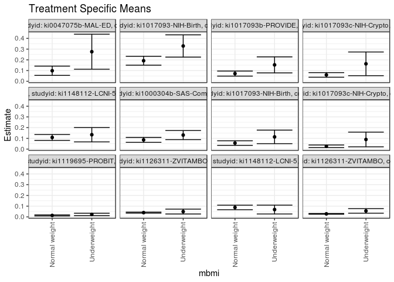

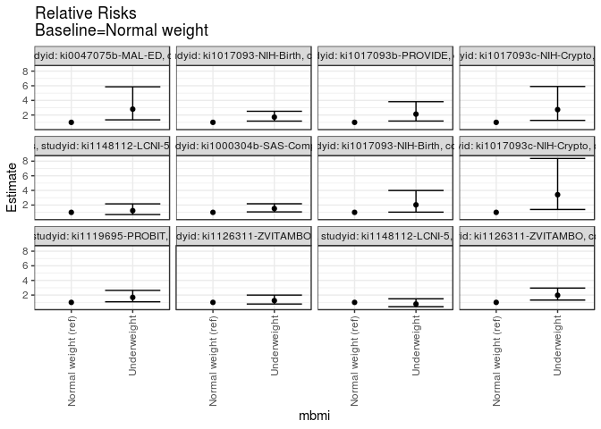

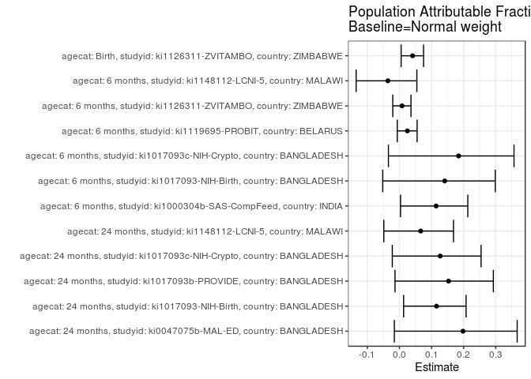

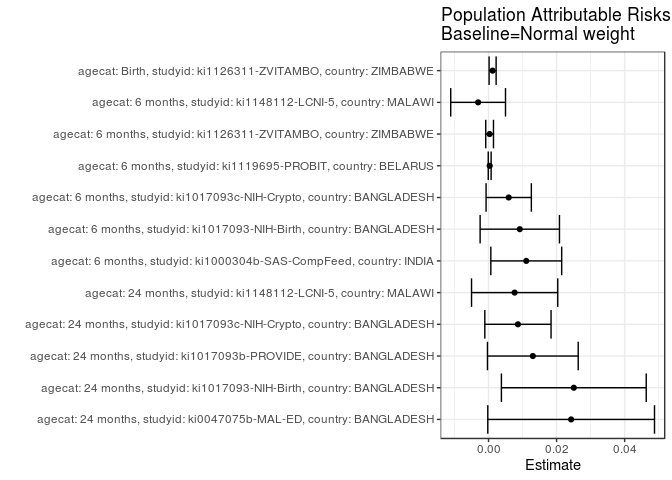

## Results Table

### Parameter: TSM

| agecat | studyid | country | intervention_level | baseline_level | estimate | ci_lower | ci_upper |
| --- | --- | --- | --- | --- | --- | --- | --- |
| Birth | ki1126311-ZVITAMBO | ZIMBABWE | Normal weight | NA | 0.0281758 | 0.0247778 | 0.0315737 |
| Birth | ki1126311-ZVITAMBO | ZIMBABWE | Underweight | NA | 0.0555804 | 0.0341587 | 0.0770021 |
| 6 months | ki1000304b-SAS-CompFeed | INDIA | Normal weight | NA | 0.0858963 | 0.0627841 | 0.1090086 |
| 6 months | ki1000304b-SAS-CompFeed | INDIA | Underweight | NA | 0.1306381 | 0.0882775 | 0.1729986 |
| 6 months | ki1017093-NIH-Birth | BANGLADESH | Normal weight | NA | 0.0559865 | 0.0345200 | 0.0774530 |
| 6 months | ki1017093-NIH-Birth | BANGLADESH | Underweight | NA | 0.1136051 | 0.0503306 | 0.1768795 |
| 6 months | ki1017093c-NIH-Crypto | BANGLADESH | Normal weight | NA | 0.0262346 | 0.0139197 | 0.0385494 |
| 6 months | ki1017093c-NIH-Crypto | BANGLADESH | Underweight | NA | 0.0895522 | 0.0211327 | 0.1579718 |
| 6 months | ki1119695-PROBIT | BELARUS | Normal weight | NA | 0.0136274 | 0.0088689 | 0.0183858 |
| 6 months | ki1119695-PROBIT | BELARUS | Underweight | NA | 0.0229517 | 0.0118564 | 0.0340469 |
| 6 months | ki1126311-ZVITAMBO | ZIMBABWE | Normal weight | NA | 0.0397712 | 0.0351047 | 0.0444378 |
| 6 months | ki1126311-ZVITAMBO | ZIMBABWE | Underweight | NA | 0.0494551 | 0.0267591 | 0.0721511 |
| 6 months | ki1148112-LCNI-5 | MALAWI | Normal weight | NA | 0.0879877 | 0.0668516 | 0.1091238 |
| 6 months | ki1148112-LCNI-5 | MALAWI | Underweight | NA | 0.0682484 | 0.0269080 | 0.1095889 |
| 24 months | ki0047075b-MAL-ED | BANGLADESH | Normal weight | NA | 0.0983607 | 0.0551116 | 0.1416097 |
| 24 months | ki0047075b-MAL-ED | BANGLADESH | Underweight | NA | 0.2758621 | 0.1128077 | 0.4389164 |
| 24 months | ki1017093-NIH-Birth | BANGLADESH | Normal weight | NA | 0.1917172 | 0.1502691 | 0.2331654 |
| 24 months | ki1017093-NIH-Birth | BANGLADESH | Underweight | NA | 0.3292026 | 0.2255536 | 0.4328517 |
| 24 months | ki1017093b-PROVIDE | BANGLADESH | Normal weight | NA | 0.0720438 | 0.0484737 | 0.0956140 |
| 24 months | ki1017093b-PROVIDE | BANGLADESH | Underweight | NA | 0.1530557 | 0.0783799 | 0.2277315 |
| 24 months | ki1017093c-NIH-Crypto | BANGLADESH | Normal weight | NA | 0.0594480 | 0.0380723 | 0.0808237 |
| 24 months | ki1017093c-NIH-Crypto | BANGLADESH | Underweight | NA | 0.1627907 | 0.0523400 | 0.2732414 |
| 24 months | ki1148112-LCNI-5 | MALAWI | Normal weight | NA | 0.1084405 | 0.0808065 | 0.1360745 |
| 24 months | ki1148112-LCNI-5 | MALAWI | Underweight | NA | 0.1338995 | 0.0671101 | 0.2006889 |

### Parameter: E(Y)

| agecat | studyid | country | intervention_level | baseline_level | estimate | ci_lower | ci_upper |
| --- | --- | --- | --- | --- | --- | --- | --- |
| Birth | ki1126311-ZVITAMBO | ZIMBABWE | NA | NA | 0.0293751 | 0.0260032 | 0.0327471 |
| 6 months | ki1000304b-SAS-CompFeed | INDIA | NA | NA | 0.0969845 | 0.0738527 | 0.1201163 |
| 6 months | ki1017093-NIH-Birth | BANGLADESH | NA | NA | 0.0651769 | 0.0442802 | 0.0860736 |
| 6 months | ki1017093c-NIH-Crypto | BANGLADESH | NA | NA | 0.0321678 | 0.0192256 | 0.0451101 |
| 6 months | ki1119695-PROBIT | BELARUS | NA | NA | 0.0139710 | 0.0092040 | 0.0187379 |
| 6 months | ki1126311-ZVITAMBO | ZIMBABWE | NA | NA | 0.0400900 | 0.0355296 | 0.0446505 |
| 6 months | ki1148112-LCNI-5 | MALAWI | NA | NA | 0.0849282 | 0.0660197 | 0.1038368 |
| 24 months | ki0047075b-MAL-ED | BANGLADESH | NA | NA | 0.1226415 | 0.0783812 | 0.1669018 |
| 24 months | ki1017093-NIH-Birth | BANGLADESH | NA | NA | 0.2167832 | 0.1777459 | 0.2558205 |
| 24 months | ki1017093b-PROVIDE | BANGLADESH | NA | NA | 0.0850694 | 0.0622663 | 0.1078726 |
| 24 months | ki1017093c-NIH-Crypto | BANGLADESH | NA | NA | 0.0680934 | 0.0462948 | 0.0898920 |
| 24 months | ki1148112-LCNI-5 | MALAWI | NA | NA | 0.1161179 | 0.0899551 | 0.1422806 |

### Parameter: RR

| agecat | studyid | country | intervention_level | baseline_level | estimate | ci_lower | ci_upper |
| --- | --- | --- | --- | --- | --- | --- | --- |
| Birth | ki1126311-ZVITAMBO | ZIMBABWE | Normal weight | Normal weight | 1.0000000 | 1.0000000 | 1.000000 |
| Birth | ki1126311-ZVITAMBO | ZIMBABWE | Underweight | Normal weight | 1.9726317 | 1.3171951 | 2.954213 |
| 6 months | ki1000304b-SAS-CompFeed | INDIA | Normal weight | Normal weight | 1.0000000 | 1.0000000 | 1.000000 |
| 6 months | ki1000304b-SAS-CompFeed | INDIA | Underweight | Normal weight | 1.5208811 | 1.0638696 | 2.174213 |
| 6 months | ki1017093-NIH-Birth | BANGLADESH | Normal weight | Normal weight | 1.0000000 | 1.0000000 | 1.000000 |
| 6 months | ki1017093-NIH-Birth | BANGLADESH | Underweight | Normal weight | 2.0291515 | 1.0317809 | 3.990630 |
| 6 months | ki1017093c-NIH-Crypto | BANGLADESH | Normal weight | Normal weight | 1.0000000 | 1.0000000 | 1.000000 |
| 6 months | ki1017093c-NIH-Crypto | BANGLADESH | Underweight | Normal weight | 3.4135206 | 1.3924201 | 8.368253 |
| 6 months | ki1119695-PROBIT | BELARUS | Normal weight | Normal weight | 1.0000000 | 1.0000000 | 1.000000 |
| 6 months | ki1119695-PROBIT | BELARUS | Underweight | Normal weight | 1.6842315 | 1.0746443 | 2.639604 |
| 6 months | ki1126311-ZVITAMBO | ZIMBABWE | Normal weight | Normal weight | 1.0000000 | 1.0000000 | 1.000000 |
| 6 months | ki1126311-ZVITAMBO | ZIMBABWE | Underweight | Normal weight | 1.2434891 | 0.7743341 | 1.996897 |
| 6 months | ki1148112-LCNI-5 | MALAWI | Normal weight | Normal weight | 1.0000000 | 1.0000000 | 1.000000 |
| 6 months | ki1148112-LCNI-5 | MALAWI | Underweight | Normal weight | 0.7756587 | 0.4044496 | 1.487568 |
| 24 months | ki0047075b-MAL-ED | BANGLADESH | Normal weight | Normal weight | 1.0000000 | 1.0000000 | 1.000000 |
| 24 months | ki0047075b-MAL-ED | BANGLADESH | Underweight | Normal weight | 2.8045976 | 1.3425593 | 5.858786 |
| 24 months | ki1017093-NIH-Birth | BANGLADESH | Normal weight | Normal weight | 1.0000000 | 1.0000000 | 1.000000 |
| 24 months | ki1017093-NIH-Birth | BANGLADESH | Underweight | Normal weight | 1.7171259 | 1.1718836 | 2.516053 |
| 24 months | ki1017093b-PROVIDE | BANGLADESH | Normal weight | Normal weight | 1.0000000 | 1.0000000 | 1.000000 |
| 24 months | ki1017093b-PROVIDE | BANGLADESH | Underweight | Normal weight | 2.1244797 | 1.1799881 | 3.824966 |
| 24 months | ki1017093c-NIH-Crypto | BANGLADESH | Normal weight | Normal weight | 1.0000000 | 1.0000000 | 1.000000 |
| 24 months | ki1017093c-NIH-Crypto | BANGLADESH | Underweight | Normal weight | 2.7383721 | 1.2706011 | 5.901680 |
| 24 months | ki1148112-LCNI-5 | MALAWI | Normal weight | Normal weight | 1.0000000 | 1.0000000 | 1.000000 |
| 24 months | ki1148112-LCNI-5 | MALAWI | Underweight | Normal weight | 1.2347744 | 0.7046465 | 2.163734 |

### Parameter: PAR

| agecat | studyid | country | intervention_level | baseline_level | estimate | ci_lower | ci_upper |
| --- | --- | --- | --- | --- | --- | --- | --- |
| Birth | ki1126311-ZVITAMBO | ZIMBABWE | Normal weight | NA | 0.0011994 | 0.0001653 | 0.0022335 |
| 6 months | ki1000304b-SAS-CompFeed | INDIA | Normal weight | NA | 0.0110882 | 0.0006771 | 0.0214993 |
| 6 months | ki1017093-NIH-Birth | BANGLADESH | Normal weight | NA | 0.0091904 | -0.0024694 | 0.0208502 |
| 6 months | ki1017093c-NIH-Crypto | BANGLADESH | Normal weight | NA | 0.0059333 | -0.0007202 | 0.0125867 |
| 6 months | ki1119695-PROBIT | BELARUS | Normal weight | NA | 0.0003436 | -0.0000798 | 0.0007670 |
| 6 months | ki1126311-ZVITAMBO | ZIMBABWE | Normal weight | NA | 0.0003188 | -0.0008193 | 0.0014569 |
| 6 months | ki1148112-LCNI-5 | MALAWI | Normal weight | NA | -0.0030595 | -0.0111079 | 0.0049890 |
| 24 months | ki0047075b-MAL-ED | BANGLADESH | Normal weight | NA | 0.0242809 | -0.0002187 | 0.0487804 |
| 24 months | ki1017093-NIH-Birth | BANGLADESH | Normal weight | NA | 0.0250660 | 0.0037857 | 0.0463463 |
| 24 months | ki1017093b-PROVIDE | BANGLADESH | Normal weight | NA | 0.0130256 | -0.0003080 | 0.0263592 |
| 24 months | ki1017093c-NIH-Crypto | BANGLADESH | Normal weight | NA | 0.0086454 | -0.0010863 | 0.0183771 |
| 24 months | ki1148112-LCNI-5 | MALAWI | Normal weight | NA | 0.0076774 | -0.0049926 | 0.0203473 |

### Parameter: PAF

| agecat | studyid | country | intervention_level | baseline_level | estimate | ci_lower | ci_upper |
| --- | --- | --- | --- | --- | --- | --- | --- |
| Birth | ki1126311-ZVITAMBO | ZIMBABWE | Normal weight | NA | 0.0408292 | 0.0052720 | 0.0751154 |
| 6 months | ki1000304b-SAS-CompFeed | INDIA | Normal weight | NA | 0.1143296 | 0.0033156 | 0.2129785 |
| 6 months | ki1017093-NIH-Birth | BANGLADESH | Normal weight | NA | 0.1410073 | -0.0520784 | 0.2986563 |
| 6 months | ki1017093c-NIH-Crypto | BANGLADESH | Normal weight | NA | 0.1844471 | -0.0343640 | 0.3569706 |
| 6 months | ki1119695-PROBIT | BELARUS | Normal weight | NA | 0.0245935 | -0.0068197 | 0.0550265 |
| 6 months | ki1126311-ZVITAMBO | ZIMBABWE | Normal weight | NA | 0.0079521 | -0.0208342 | 0.0359268 |
| 6 months | ki1148112-LCNI-5 | MALAWI | Normal weight | NA | -0.0360241 | -0.1349275 | 0.0542604 |
| 24 months | ki0047075b-MAL-ED | BANGLADESH | Normal weight | NA | 0.1979823 | -0.0158966 | 0.3668329 |
| 24 months | ki1017093-NIH-Birth | BANGLADESH | Normal weight | NA | 0.1156269 | 0.0129701 | 0.2076069 |
| 24 months | ki1017093b-PROVIDE | BANGLADESH | Normal weight | NA | 0.1531174 | -0.0139209 | 0.2926369 |
| 24 months | ki1017093c-NIH-Crypto | BANGLADESH | Normal weight | NA | 0.1269639 | -0.0222870 | 0.2544246 |
| 24 months | ki1148112-LCNI-5 | MALAWI | Normal weight | NA | 0.0661171 | -0.0487103 | 0.1683715 |